# Machine Learning 2019: Hw4

Tayler Sindhu

November 4, 2019

## Homework

1. Compare the most important features from at least 2 different classes of feature selection methods covered in this tutorial with any reasonable machine learning dataset from mlbench. Do these feature selection methods provide similar results?
2. Attempt a feature selection method not covered in this tutorial (backward elimination, forward propogation, etc.)

### **Question 1**

```r
# load data
data(Glass)

# Check variable types
str(Glass)
```

```
## 'data.frame':    214 obs. of  10 variables:
##  $ RI  : num  1.52 1.52 1.52 1.52 1.52 ...
##  $ Na  : num  13.6 13.9 13.5 13.2 13.3 ...
##  $ Mg  : num  4.49 3.6 3.55 3.69 3.62 3.61 3.6 3.61 3.58 3.6 ...
##  $ Al  : num  1.1 1.36 1.54 1.29 1.24 1.62 1.14 1.05 1.37 1.36 ...
##  $ Si  : num  71.8 72.7 73 72.6 73.1 ...
##  $ K   : num  0.06 0.48 0.39 0.57 0.55 0.64 0.58 0.57 0.56 0.57 ...
##  $ Ca  : num  8.75 7.83 7.78 8.22 8.07 8.07 8.17 8.24 8.3 8.4 ...
##  $ Ba  : num  0 0 0 0 0 0 0 0 0 0 ...
##  $ Fe  : num  0 0 0 0 0 0.26 0 0 0 0.11 ...
##  $ Type: Factor w/ 6 levels "1","2","3","5",..: 1 1 1 1 1 1 1 1 1 1 ...
```

```r
# Confirm that there are no Na values
sum(is.na(Glass))
```

```
## [1] 0
```

```r
# Change outcome variables from numbers to letters to avoid errors in algorithms
levels(Glass[,10]) <- c("one", "two", "three", "five", "six", "seven")
```

```r
# Question 1
# wrapper method

# define control
control = rfeControl(functions = caretFuncs, number = 2)

# recursive feature elimination algorithm
results <- rfe(Glass[,1:9], Glass[,10], sizes = c(2,5,6,9), rfeControl = control, method = "svmRadial")

results
```

```
##
## Recursive feature selection
##
## Outer resampling method: Bootstrapped (2 reps)
##
## Resampling performance over subset size:
##
##  Variables Accuracy  Kappa AccuracySD  KappaSD Selected
##          2   0.6510 0.4913  0.0516486 0.074062
##          5   0.6938 0.5515  0.0440877 0.067757
##          6   0.6994 0.5558  0.0008519 0.006843        *
##          9   0.6693 0.5129  0.0434487 0.073082
##
## The top 5 variables (out of 6):
##    Mg, Al, Na, K, Ca
```

```r
results$variables
```

```
##          one       two     three      five       six     seven   Overall
## 1  0.6265419 1.0000000 1.0000000 0.9990253 0.6265419 1.0000000 0.8753515
## 2  0.6754729 0.9629187 0.7935223 1.0000000 0.6754729 0.9629187 0.8450509
## 3  0.6999428 0.5510896 0.9615385 0.9858674 0.6688179 0.6999428 0.7611998
## 4  0.6616133 0.5299043 1.0000000 0.8148148 0.6005435 0.6616133 0.7114149
## 5  0.6455950 0.8163876 0.7884615 0.5543372 0.6052989 0.8163876 0.7044113
## 6  0.7182494 0.5362870 0.5678138 0.6866472 0.6484375 0.7182494 0.6459474
## 7  0.5469108 0.6674641 0.6538462 0.7826511 0.5332880 0.6674641 0.6419374
## 8  0.5434783 0.5262130 0.5657895 0.9137427 0.5262130 0.5434783 0.6031524
## 9  0.5463387 0.5729665 0.6973684 0.6335283 0.5940897 0.5729665 0.6028763
## 10 0.6265419 1.0000000 1.0000000 0.9990253 0.6265419 1.0000000 0.8753515
## 11 0.6754729 0.9629187 0.7935223 1.0000000 0.6754729 0.9629187 0.8450509
## 12 0.6999428 0.5510896 0.9615385 0.9858674 0.6688179 0.6999428 0.7611998
## 13 0.6616133 0.5299043 1.0000000 0.8148148 0.6005435 0.6616133 0.7114149
## 14 0.6455950 0.8163876 0.7884615 0.5543372 0.6052989 0.8163876 0.7044113
```

[output cut: 75 more lines]

```r
# random forest

# make training and test sets
train_size <- floor(0.75 * nrow(Glass))
set.seed(15)
train_pos <- sample(seq_len(nrow(Glass)), size = train_size)

train_classification <- Glass[train_pos, ]
test_classification <- Glass[-train_pos, ]

#fit model
rfmodel = randomForest(Type ~ ., data=train_classification,  importance = TRUE, oob.times = 15, confusion = TRUE)

#rank features based on importance
importance(rfmodel, type=2)
```

```
##    MeanDecreaseGini
## RI        16.462485
## Na        12.745433
## Mg        20.395397
## Al        17.305782
## Si         9.379241
## K         10.987030
## Ca        14.911109
## Ba         9.158692
## Fe         4.997065
```

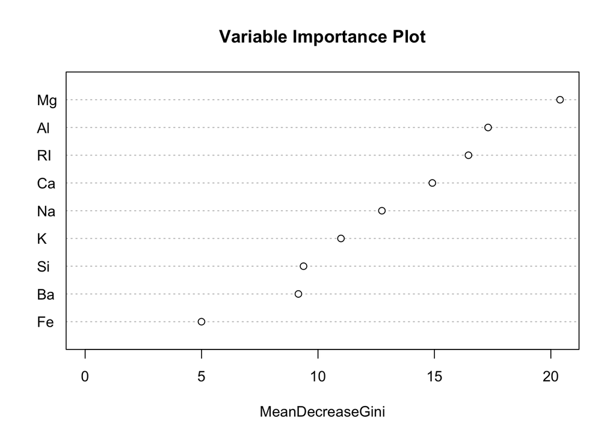

```r
# visualizing feature importance
varImpPlot(rfmodel, type=2, main = "Variable Importance Plot")
```

#### Overall, these methods produced similar results. Random forest selected Mg, Al, RI, Ca and Na to be the top 5 most important variables, while recursive feature elimination chose the top five variables to be Mg, Al, Na, K, and Ca. Only the variables RI and K did not overlap; however, K was the sixth most important variable according to the random forest model.

### **Question 2**

```r
# Filter selection with univariate filters

# Set training and test sets
set.seed(10)
train_size_sbf <- floor(0.75 * nrow(Glass))
train_pos_sbf <- sample(seq_len(nrow(Glass)), size = train_size_sbf)

train_classification_sbf <- Glass[train_pos_sbf, ]
test_classification_sbf <- Glass[-train_pos_sbf, ]

# make control

sbf_ctrl <- sbfControl(functions = caretSBF, method = "cv")

# make model
results_sbf <- sbf(train_classification_sbf[,1:9], train_classification_sbf$Type, sbfControl = sbf_ctrl)

# Display chosen variable

results_sbf
```

```
##
## Selection By Filter
##
## Outer resampling method: Cross-Validated (10 fold)
##
## Resampling performance:
##
##  Accuracy  Kappa AccuracySD KappaSD
##    0.7119 0.6053    0.06881 0.09341
##
## Using the training set, 6 variables were selected:
##    Na, Mg, Al, K, Ca...
##
## During resampling, the top 5 selected variables (out of a possible 7):
##    Al (100%), Ba (100%), K (100%), Mg (100%), Na (100%)
##
## On average, 6 variables were selected (min = 5, max = 7)
```

```r
results_sbf$variables
```

```
## $selectedVars
## [1] "Na" "Mg" "Al" "K"  "Ca" "Ba" "Fe"
##
## $selectedVars
## [1] "Na" "Mg" "Al" "K"  "Ca" "Ba"
##
## $selectedVars
## [1] "Na" "Mg" "Al" "K"  "Ca" "Ba"
##
## $selectedVars
## [1] "Na" "Mg" "Al" "K"  "Ca" "Ba"
##
## $selectedVars
## [1] "Na" "Mg" "Al" "K"  "Ca" "Ba"
##
## $selectedVars
## [1] "Na" "Mg" "Al" "K"  "Ba"
##
## $selectedVars
## [1] "Na" "Mg" "Al" "K"  "Ba" "Fe"
##
## $selectedVars
## [1] "Na" "Mg" "Al" "K"  "Ca" "Ba" "Fe"
##
## $selectedVars
## [1] "Na" "Mg" "Al" "K"  "Ca" "Ba"
##
## $selectedVars
## [1] "Na" "Mg" "Al" "K"  "Ba"
```